# Practical Demo: Constructing a Benchmark-Aware Bond Portfolio

- Show All Code
- Hide All Code
- View Source

From cash to a cell-matched portfolio and a multi-factor portfolio

## The investment decision

A manager receives **$50 million in cash and owns no bonds**. Construct a benchmark-aware bond portfolio in two ways:

1. **Cell-based construction:** match the benchmark’s sector/maturity buckets, then choose weights close to the individual benchmark bond weights.
2. **Multi-factor construction:** choose bond weights that minimize predicted tracking error using Treasury key-rate and spread-factor exposures.

Both methods use the same benchmark, investable universe, cash budget, and portfolio limits. The cell method additionally requires exact cell weights. There are no starting bond holdings, sales, or rebalancing turnover penalties. Every nonzero position is an initial purchase.

Assume **zero transaction costs, fees, and bid-ask frictions**. All $50 million is invested in bonds. Credit spreads remain market-risk inputs, not charges for purchasing bonds.

All bond descriptions, analytics, spreads, and risk estimates below are **illustrative inputs**, not market observations or executable quotes. Weights are fractions of total portfolio market value; all amounts are in US dollars.

## 1 Specify the mandate

| Requirement | Limit |
| --- | --- |
| Initial cash to invest | $50 million |
| Portfolio positions | Long-only; portfolio weights sum to 100% |
| Maximum weight in one bond | 18% of the portfolio |
| Minimum Treasury weight | 25% |
| Maximum corporate weight | 50% |
| Duration versus benchmark | Within 0.05 years |
| Weighted yield proxy versus benchmark | At least 2 bp higher |

The modest yield-proxy floor gives both constructors a deliberate active objective. It is not a forecast of excess return. No hard tracking-error limit is imposed: both portfolios are evaluated with the same model, and the multi-factor constructor minimizes that measure.

### 1.1 Allocate the full cash budget

Let $B$ be the initial $50 million and $w_i$ the portfolio weight of bond $i$. Buy $Bw_i$ of that bond. Full investment requires

$$\sum_iw_i=1,\qquad\sum_iBw_i=B.$$

There is no deduction from initial cash: the sum of the bond purchases equals $50 million for both construction methods.

**Show calculation**

```python
import numpy as np
import pandas as pd
from scipy.optimize import linprog, minimize, brentq
budget = 50_000_000.0
position_cap = .18
treasury_minimum = .25
corporate_cap = .50
duration_tolerance = .05
carry_increment = .0002
universe = pd.DataFrame({
    "Bond": ["UST 2Y", "UST 5Y", "UST 10Y", "Agency 3Y", "Agency 7Y",
             "Bank A 3Y", "Bank B 5Y", "Utility A 7Y", "Industrial A 10Y",
             "Industrial B 5Y", "Telecom A 10Y", "Consumer A 7Y"],
    "Sector": ["Treasury", "Treasury", "Treasury", "Agency", "Agency",
               "Corporate", "Corporate", "Corporate", "Corporate",
               "Corporate", "Corporate", "Corporate"],
    "Coupon rate": [0.0415, 0.0435, 0.0455, 0.0442, 0.0470, 0.0505,
              0.0528, 0.0555, 0.0585, 0.0540, 0.0600, 0.0562],
    "Spread (bp)": [0, 0, 0, 38, 55, 92, 112, 138, 165, 125, 182, 148],
    "Benchmark weight": [0.10, 0.13, 0.10, 0.09, 0.10, 0.07,
                         0.09, 0.08, 0.07, 0.07, 0.05, 0.05],
})
universe['Maturity (years)'] = [2,5,10,3,7,3,5,7,10,5,10,7]
universe['Cell'] = universe['Sector'] + ' / ' + pd.cut(universe['Maturity (years)'],[0,4,8,np.inf],labels=['0-4Y','4-8Y','8Y+'],right=True).astype(str)
# Curve quotes and coupons are annualized, with semiannual compounding/payments.
node_times = np.array([2., 5., 10.])
node_zero_rates = np.array([.0415, .0435, .0455])
payment_times = np.arange(1, 2 * int(universe['Maturity (years)'].max()) + 1) / 2
maturities = universe['Maturity (years)'].to_numpy()
coupon_rates = universe['Coupon rate'].to_numpy()
cashflows = np.where(payment_times[None, :] <= maturities[:, None],
                     100 * coupon_rates[:, None] / 2, 0.)
cashflows += 100 * (payment_times[None, :] == maturities[:, None])
# Unit node bumps interpolate linearly; the 2Y bump is flat before 2Y.
key_basis = np.column_stack([np.interp(payment_times, node_times, np.eye(3)[k])
                             for k in range(3)])
treasury_zeros = np.interp(payment_times, node_times, node_zero_rates)
base_rates = treasury_zeros[None, :] + universe['Spread (bp)'].to_numpy()[:, None] / 10000
pv_cashflows = cashflows / (1 + base_rates / 2)**(2 * payment_times)
full_prices = pv_cashflows.sum(axis=1)
weighted_sensitivities = (pv_cashflows / full_prices[:, None]
                         * payment_times / (1 + base_rates / 2))
key_durations = weighted_sensitivities @ key_basis
universe[['KRD 2', 'KRD 5', 'KRD 10']] = key_durations
universe['Duration'] = weighted_sensitivities.sum(axis=1)
universe['Convexity'] = (pv_cashflows * payment_times * (payment_times + .5)
                         / (1 + base_rates / 2)**2).sum(axis=1) / full_prices
universe['Full price'] = full_prices
# Each YTM discounts that bond's own cash flows back to its computed full price.
universe['Yield'] = [brentq(lambda y: np.sum(cf / (1 + y / 2)**(2 * payment_times)) - price,
                           -.5, .5) for cf, price in zip(cashflows, full_prices)]
universe['Spread duration'] = np.where(universe['Sector'].eq('Treasury'), 0., universe['Duration'])

benchmark = universe['Benchmark weight'].to_numpy()
yields = universe['Yield'].to_numpy()
durations = universe['Duration'].to_numpy()
treasury = universe['Sector'].eq('Treasury').to_numpy()
corporate = universe['Sector'].eq('Corporate').to_numpy()
spread_beta = np.where(corporate,1.,np.where(universe['Sector'].eq('Agency'),.25,0.))
```

## 2 Define the investable bonds and benchmark

The benchmark is an explicitly supplied set of bond weights. It is a reference index, not an existing client portfolio. Both constructors may buy any of the 12 securities below. Each corporate label represents a different issuer, so bond concentration and issuer concentration coincide within this universe.

All bonds are illustrative dollar-denominated, option-free, fixed-coupon bonds with semiannual payments and $100 face value. Settlement is immediately after a coupon date, so accrued interest is zero. Coupons are supplied inputs; prices, yields, durations, and convexities are calculated from those cash flows.

The Treasury zero curve has rates of **4.15%, 4.35%, and 4.55% at 2, 5, and 10 years**, quoted annually with semiannual compounding. Zero rates interpolate linearly between nodes and stay flat before 2 years. Every payment is within 10 years. The supplied spread is a constant addition to this zero curve, in basis points under the same compounding convention; Treasury spreads are zero.

Individual yields to maturity are quoted annually with semiannual compounding. The weighted yield remains a proxy, not the portfolio cash-flow internal rate of return. The weighted average zero-curve spread is likewise a proxy, not a separately solved portfolio spread.

### 2.1 Benchmark weights and classification

**Show calculation**

```python
benchmark_view = universe[['Bond','Sector','Maturity (years)']].copy()
benchmark_view['Benchmark (%)'] = 100*benchmark
show_table(benchmark_view,2)
assert np.isclose(benchmark.sum(),1)
assert np.all(benchmark>=0)
```

| Bond | Sector | Maturity (years) | Benchmark (%) |
| --- | --- | --- | --- |
| UST 2Y | Treasury | 2 | 10.00 |
| UST 5Y | Treasury | 5 | 13.00 |
| UST 10Y | Treasury | 10 | 10.00 |
| Agency 3Y | Agency | 3 | 9.00 |
| Agency 7Y | Agency | 7 | 10.00 |
| Bank A 3Y | Corporate | 3 | 7.00 |
| Bank B 5Y | Corporate | 5 | 9.00 |
| Utility A 7Y | Corporate | 7 | 8.00 |
| Industrial A 10Y | Corporate | 10 | 7.00 |
| Industrial B 5Y | Corporate | 5 | 7.00 |
| Telecom A 10Y | Corporate | 10 | 5.00 |
| Consumer A 7Y | Corporate | 7 | 5.00 |

### 2.2 Yields, spreads, and prices

Yields and zero-curve spreads describe the bonds’ pricing and market exposure. The calculated full prices below determine how much face value a dollar allocation represents.

**Show calculation**

```python
view = universe[['Bond','Spread (bp)']].copy()
view.insert(1,'Yield (%)',100*yields)
show_table(view,2)
price_view = universe[['Bond','Full price']].copy()
price_view.insert(1,'Coupon (%)',100*coupon_rates)
show_table(price_view,3)
```

| Bond | Yield (%) | Spread (bp) |
| --- | --- | --- |
| UST 2Y | 4.15 | 0 |
| UST 5Y | 4.34 | 0 |
| UST 10Y | 4.52 | 0 |
| Agency 3Y | 4.59 | 38 |
| Agency 7Y | 4.96 | 55 |
| Bank A 3Y | 5.13 | 92 |
| Bank B 5Y | 5.46 | 112 |
| Utility A 7Y | 5.79 | 138 |
| Industrial A 10Y | 6.16 | 165 |
| Industrial B 5Y | 5.59 | 125 |
| Telecom A 10Y | 6.33 | 182 |
| Consumer A 7Y | 5.89 | 148 |

| Bond | Coupon (%) | Full price |
| --- | --- | --- |
| UST 2Y | 4.150 | 100.000 |
| UST 5Y | 4.350 | 100.049 |
| UST 10Y | 4.550 | 100.257 |
| Agency 3Y | 4.420 | 99.518 |
| Agency 7Y | 4.700 | 98.469 |
| Bank A 3Y | 5.050 | 99.771 |
| Bank B 5Y | 5.280 | 99.236 |
| Utility A 7Y | 5.550 | 98.645 |
| Industrial A 10Y | 5.850 | 97.725 |
| Industrial B 5Y | 5.400 | 99.197 |
| Telecom A 10Y | 6.000 | 97.604 |
| Consumer A 7Y | 5.620 | 98.481 |

### 2.3 Treasury and spread sensitivities

Key-rate durations and spread durations are measured in years. Convexity is measured in years squared. These are **calculated sensitivities**, not assigned allocations of a supplied duration.

For cash flows $CF_{i,t}$, the price per $100 face is

$$P_i=\sum_t CF_{i,t}\left(1+\frac{z(t)+s_i}{2}\right)^{-2t}.$$

A key-rate shock moves one zero-curve node and linearly interpolates that move between neighboring nodes, holding the other node quotes fixed. The 2Y node also controls rates before 2 years. The three unit bump functions sum to one, so the three key-rate durations add to parallel zero-curve duration.

The **2Y Treasury has zero 5Y and 10Y sensitivity**: neither bump changes any rate used to discount its cash flows. Every bond maturing at 5 years or earlier has zero 10Y sensitivity. A 3Y bond can have 5Y sensitivity because its later cash flows fall between the 2Y and 5Y nodes. A 5Y bond can have 2Y sensitivity through its earlier coupons.

For these option-free bonds, shifting the full Treasury zero curve or the bond’s constant spread has the same discount-rate effect. Non-Treasury spread duration therefore equals parallel rate duration in this model. Treasury spread sensitivity is zero because Treasury spreads are held at zero.

**Show calculation**

```python
show_table(universe[['Bond','KRD 2','KRD 5','KRD 10','Spread duration']],2)
show_table(universe[['Bond','Duration','Convexity']],2)
```

| Bond | KRD 2 | KRD 5 | KRD 10 | Spread duration |
| --- | --- | --- | --- | --- |
| UST 2Y | 1.90 | 0.00 | 0.00 | 0.00 |
| UST 5Y | 0.25 | 4.20 | 0.00 | 0.00 |
| UST 10Y | 0.26 | 0.77 | 6.93 | 0.00 |
| Agency 3Y | 1.89 | 0.88 | 0.00 | 2.78 |
| Agency 7Y | 0.27 | 3.54 | 2.08 | 5.89 |
| Bank A 3Y | 1.88 | 0.87 | 0.00 | 2.75 |
| Bank B 5Y | 0.29 | 4.04 | 0.00 | 4.34 |
| Utility A 7Y | 0.31 | 3.44 | 1.97 | 5.72 |
| Industrial A 10Y | 0.32 | 0.92 | 6.19 | 7.44 |
| Industrial B 5Y | 0.30 | 4.03 | 0.00 | 4.32 |
| Telecom A 10Y | 0.33 | 0.93 | 6.12 | 7.38 |
| Consumer A 7Y | 0.31 | 3.43 | 1.96 | 5.70 |

| Bond | Duration | Convexity |
| --- | --- | --- |
| UST 2Y | 1.90 | 4.61 |
| UST 5Y | 4.45 | 23.18 |
| UST 10Y | 7.96 | 75.83 |
| Agency 3Y | 2.78 | 9.33 |
| Agency 7Y | 5.89 | 40.89 |
| Bank A 3Y | 2.75 | 9.19 |
| Bank B 5Y | 4.34 | 22.31 |
| Utility A 7Y | 5.72 | 39.17 |
| Industrial A 10Y | 7.44 | 68.71 |
| Industrial B 5Y | 4.32 | 22.20 |
| Telecom A 10Y | 7.38 | 67.96 |
| Consumer A 7Y | 5.70 | 39.01 |

## 3 Identify the four risk factors

A **factor is a market change**. A duration is a security’s **sensitivity** to that change. The risk model contains exactly four common factors:

| Factor | Change being modeled | Bond sensitivity |
| --- | --- | --- |
| 2Y Treasury yield | Change at the 2-year Treasury node | 2Y key-rate duration |
| 5Y Treasury yield | Change at the 5-year Treasury node | 5Y key-rate duration |
| 10Y Treasury yield | Change at the 10-year Treasury node | 10Y key-rate duration |
| Common spread | Change in the common corporate-spread driver | Spread duration times sector beta |

The spread-driver beta is **0 for Treasuries, 0.25 for agencies, and 1 for corporates**. A +100 bp common-spread shock therefore means unchanged Treasury spreads, +25 bp agency spreads, and +100 bp corporate spreads. This same scaling is used in both predicted risk and scenarios.

There is no separate level factor on top of the three key rates. A parallel Treasury move means applying the same change to all three nodes; adding another level shock would count that move twice.

### 3.1 Return mapping and units

For changes measured in basis points, the first-order bond return in basis points is

$$r_i\approx-KRD_{i,2}\Delta y_2-KRD_{i,5}\Delta y_5
-KRD_{i,10}\Delta y_{10}-\beta_iSD_i\Delta s+\epsilon_i.$$

For example, the 5Y Treasury has 5Y key-rate duration **4.203 years**. A 10 bp increase at that node implies a first-order loss of approximately **42.03 bp**. Bank B’s spread duration is **4.337 years**, implying approximately **43.37 bp** of loss for a 10 bp common-spread increase with Treasury yields unchanged.

Here $\epsilon_i$ is security-specific return. Residuals are assumed mutually independent and independent of all four common factors. The model omits additional rating, sector, liquidity, currency, and option factors.

**Show calculation**

```python
# Factors are yield/spread CHANGES; durations are exposures to those changes.
factor_names = ['2Y Treasury yield','5Y Treasury yield','10Y Treasury yield','Common spread']
exposures = np.column_stack([universe[['KRD 2','KRD 5','KRD 10']].to_numpy(),
                            universe['Spread duration'].to_numpy()*spread_beta])
loadings = -exposures
factor_vol_bp = np.array([70.,80.,90.,60.])
correlation = np.array([[1,.82,.62,.05],[.82,1,.85,.08],[.62,.85,1,.10],[.05,.08,.10,1]])
factor_covariance_bp2 = np.outer(factor_vol_bp,factor_vol_bp)*correlation
specific_vol_bp = np.where(corporate,100.,30.)
security_covariance_bp2 = loadings @ factor_covariance_bp2 @ loadings.T + np.diag(specific_vol_bp**2)
cell_indicators = pd.get_dummies(universe['Cell'],dtype=float)
cell_matrix = cell_indicators.to_numpy().T
cell_names = cell_indicators.columns.tolist()
cell_targets = cell_matrix @ benchmark
benchmark_duration = benchmark @ durations
benchmark_yield = benchmark @ yields
```

### 3.2 Factor volatilities, correlations, and residual risk

All volatilities are **annualized**, and predicted tracking error is annualized. Factor volatilities below are volatilities of yield/spread changes in bp per square-root year; residual volatilities are bond-return volatilities in the same time units. They are supplied inputs, not estimates from the bond table.

**Show calculation**

```python
show_table(pd.DataFrame({'Factor':factor_names,'Annual shock volatility (bp)':factor_vol_bp}),1)
correlation_view=pd.DataFrame(correlation,columns=['2Y','5Y','10Y','Spread'])
correlation_view.insert(0,'Factor',['2Y','5Y','10Y','Spread'])
show_table(correlation_view,2)
show_table(pd.DataFrame({'Residual group':['Treasury / agency','Corporate'],
                        'Annual residual return volatility (bp)':[30,100]}),0)
```

| Factor | Annual shock volatility (bp) |
| --- | --- |
| 2Y Treasury yield | 70.0 |
| 5Y Treasury yield | 80.0 |
| 10Y Treasury yield | 90.0 |
| Common spread | 60.0 |

| Factor | 2Y | 5Y | 10Y | Spread |
| --- | --- | --- | --- | --- |
| 2Y | 1.00 | 0.82 | 0.62 | 0.05 |
| 5Y | 0.82 | 1.00 | 0.85 | 0.08 |
| 10Y | 0.62 | 0.85 | 1.00 | 0.10 |
| Spread | 0.05 | 0.08 | 0.10 | 1.00 |

| Residual group | Annual residual return volatility (bp) |
| --- | --- |
| Treasury / agency | 30 |
| Corporate | 100 |

The factor covariance matrix is $\Sigma_F=\operatorname{diag}(\sigma_F)\rho\operatorname{diag}(\sigma_F)$, in squared basis points. Correlations are assumed fixed for this exercise. In practice they require a separate historical or forward-looking risk-estimation process; security terms and benchmark weights alone do not determine them.

## 4 Map holdings into active risk

### 4.1 Calculate portfolio and benchmark exposures

$x_{i,k}$ is bond $i$’s exposure to factor $k$; $w_{p,i}$ and $w_{b,i}$ are its portfolio and benchmark weights. Exposures are the duration sensitivities below, measured in years.

| Factor $k$ | Security exposure $x_{i,k}$ |
| --- | --- |
| 2Y Treasury yield | $KRD_{i,2}$ |
| 5Y Treasury yield | $KRD_{i,5}$ |
| 10Y Treasury yield | $KRD_{i,10}$ |
| Common spread | $\beta_i SD_i$ |

Multiply each bond’s sensitivity by its weight, then sum across all bonds:

$$x_{p,k}=\sum_i w_{p,i}x_{i,k},\qquad
x_{b,k}=\sum_i w_{b,i}x_{i,k}.$$

For example, a bond with exposure of 6 years to one factor, held at 2% in the portfolio, contributes $0.02(6)=0.12$ years to portfolio exposure. If its benchmark weight is 1.5%, its contribution to benchmark exposure is $0.015(6)=0.09$ years. These are one bond’s contributions; total exposures also include every other bond.

### 4.2 Subtract to obtain active exposures

Active exposure is portfolio exposure minus benchmark exposure:

$$\Delta x_k=x_{p,k}-x_{b,k}
=\sum_i(w_{p,i}-w_{b,i})x_{i,k}.$$

Define active bond weights as $a_i=w_{p,i}-w_{b,i}$. In the example, the bond’s active weight is **0.5 percentage points**, and its contribution to active factor exposure is $0.005(6)=0.03$ years. Other bonds’ active contributions may reinforce or offset it.

Let $X$ be the security-exposure matrix: one row per bond and one column per factor. With weights written as column vectors,

$$\mathbf{x}_p=X'\mathbf{w}_p,\qquad
\mathbf{x}_b=X'\mathbf{w}_b,\qquad
\Delta\mathbf{x}=X'\mathbf{a}.$$

Thus **weights create exposures, and differences in weights create active exposures**. Section 6 applies these calculations to the constructed portfolios.

### 4.3 Distinguish exposure from the signed return loading

The factors here are upward changes in yields and spreads. Because price falls when those rates rise, their first-order active-return effect is

$$\Delta R_{\mathrm{active}}\approx-\sum_k\Delta x_k F_k.$$

For instance, an active duration of +0.20 years produces approximately $-0.20(10)=-2$ bp of active return for a +10 bp factor shock.

The code therefore uses the **return-loading matrix** $L=-X$. Multiplying active weights by this matrix gives:

$$\mathbf{a}'L=-(\Delta\mathbf{x})'.$$

It is the vector of signed active return loadings. The positive-duration exposure convention remains $\Delta x_k=x_{p,k}-x_{b,k}$.

### 4.4 Convert active exposures into predicted tracking error

Use the active-exposure vector, factor covariance, and residual active variance:

$$TE=\sqrt{(\Delta\mathbf{x})'\Sigma_F(\Delta\mathbf{x})
+\sigma_\epsilon^2},\qquad
\sigma_\epsilon^2=\sum_i a_i^2\sigma_{\epsilon,i}^2.$$

The residual formula assumes independent bond residuals. Inserting $L=-X$ gives the identical systematic variance: the minus signs appear on both sides of $\Sigma_F$ and cancel. The square root is annual TE in basis points, consistent with the supplied annual factor and residual volatilities.

Portfolio and benchmark weights both sum to one and refer to the same $50 million capital base. Their active weights therefore sum to zero.

## 5 Construct the two portfolios

### 5.1 Method 1: exact cell matching

Define cells by **sector** and **remaining maturity**. Sectors are Treasury, agency, and corporate; maturity buckets are $(0,4]$, $(4,8]$, and over 8 years. There are nine possible cells and eight occupied cells in this universe.

**Show calculation**

```python
cell_view=pd.DataFrame({'Cell':cell_names,'Benchmark %':100*cell_targets})
show_table(cell_view,2)
assert np.isclose(cell_targets.sum(),1)
```

| Cell | Benchmark % |
| --- | --- |
| Agency / 0-4Y | 9.00 |
| Agency / 4-8Y | 10.00 |
| Corporate / 0-4Y | 7.00 |
| Corporate / 4-8Y | 29.00 |
| Corporate / 8Y+ | 12.00 |
| Treasury / 0-4Y | 10.00 |
| Treasury / 4-8Y | 13.00 |
| Treasury / 8Y+ | 10.00 |

For each occupied cell $g$, require

$$\sum_{i\in g}w_i=\sum_{i\in g}w_{B,i}.$$

Within those cell budgets, keep individual bond weights as close as possible to their benchmark weights, subject to all common mandate limits:

$$\min_w\sum_i(w_i-w_{b,i})^2.$$

Duration and yield are guardrails. **This selection rule uses weight differences, not factor covariance or predicted tracking error.** It makes the choice within each cell explicit. The resulting portfolio is assessed with the shared risk model afterward.

### 5.2 Method 2: multi-factor risk minimization

Remove the exact-cell constraints and instead minimize the common model’s predicted tracking-error variance:

$$\min_w\;TE(w)^2.$$

Keep every common mandate limit, including duration, concentration, sector, and yield-proxy floor. The optimizer can shift between cells when that improves the combined factor and residual risk. The benchmark itself has zero TE but fails the required 2 bp yield-proxy increment.

Both problems use long-only weights summing to one. Dividing risk variance by 10,000 in the calculation is only numerical scaling; it does not change the solution. A linear program first finds feasible weights; the relevant objective then selects the final weights. The starting point is not an existing portfolio.

**Show calculation**

```python
def tracking_variance(weights):
    active = np.asarray(weights)-benchmark
    return active @ security_covariance_bp2 @ active

def purchase_values(weights):
    return budget * np.asarray(weights)

def construct(method, increment=carry_increment, maximize_carry=False):
    # Every inequality is written as A w <= b, in decimal yields and years.
    A = np.vstack([-treasury.astype(float),corporate.astype(float),durations,-durations,
                   -yields])
    b = np.array([-treasury_minimum,corporate_cap,benchmark_duration+duration_tolerance,
                  -benchmark_duration+duration_tolerance,
                  -(benchmark_yield+increment)])
    eq = cell_matrix if method=='Cell-based' else np.ones((1,len(universe)))
    eq_target = cell_targets if method=='Cell-based' else np.array([1.])
    bounds = [(0.,position_cap)]*len(universe)
    # Feasibility first; the ceiling exercise maximizes yield instead.
    seed = linprog(-yields if maximize_carry else np.zeros(len(universe)),A_ub=A,b_ub=b,A_eq=eq,b_eq=eq_target,bounds=bounds,method='highs')
    if not seed.success:
        raise ValueError(f'{method}: mandate infeasible: {seed.message}')
    if maximize_carry:
        weights=seed.x
    else:
        scale=np.maximum(np.max(np.abs(A),axis=1),1e-12)
        An=A/scale[:,None]; bn=b/scale
        metric = np.eye(len(universe)) if method=='Cell-based' else security_covariance_bp2/10000
        result=minimize(lambda w:(w-benchmark)@metric@(w-benchmark),seed.x,
                        jac=lambda w:2*metric@(w-benchmark),
                        method='SLSQP',bounds=bounds,
                        constraints=[{'type':'eq','fun':lambda w:eq@w-eq_target,'jac':lambda w:eq},
                                     {'type':'ineq','fun':lambda w:bn-An@w,'jac':lambda w:-An}],
                        options={'ftol':1e-10,'maxiter':2000})
        if not result.success: raise RuntimeError(result.message)
        weights=result.x
    assert np.isclose(weights.sum(),1,atol=1e-8)
    assert weights.min()>=-1e-8 and weights.max()<=position_cap+1e-8
    assert (A@weights<=b+1e-8).all()
    assert np.allclose(eq@weights,eq_target,atol=1e-8)
    assert np.isclose(purchase_values(weights).sum(),budget,atol=.01,rtol=0)
    return weights
```

**Show calculation**

```python
cell_weights=construct('Cell-based')
factor_weights=construct('Multi-factor')
portfolios={'Benchmark':benchmark,'Cell-based':cell_weights,'Multi-factor':factor_weights}

def summary(weights):
    return pd.Series({'Yield proxy (%)':100*weights@yields,'Duration (years)':weights@durations,
                      'Average spread (bp)':weights@universe['Spread (bp)'],
                      'Treasury (%)':100*weights[treasury].sum(),'Corporate (%)':100*weights[corporate].sum(),
                      'Largest bond (%)':100*weights.max(),'Annual TE (bp)':np.sqrt(tracking_variance(weights)),
                      'Bonds ($m)':purchase_values(weights).sum()/1e6})
comparison=pd.DataFrame({name:summary(w) for name,w in portfolios.items()}).T
```

## 6 Compare the constructed portfolios

### 6.1 Bond allocations

All portfolio weights below are percentages of their invested portfolio. A zero weight means the constructor does not buy that security.

**Show calculation**

```python
weights_view=pd.DataFrame({'Bond':universe['Bond'],'Benchmark (%)':100*benchmark,
                           'Cell (%)':100*cell_weights,'Multi-factor (%)':100*factor_weights})
show_table(weights_view,2)
```

| Bond | Benchmark (%) | Cell (%) | Multi-factor (%) |
| --- | --- | --- | --- |
| UST 2Y | 10.00 | 10.00 | 7.68 |
| UST 5Y | 13.00 | 13.00 | 9.95 |
| UST 10Y | 10.00 | 10.00 | 9.66 |
| Agency 3Y | 9.00 | 9.00 | 12.10 |
| Agency 7Y | 10.00 | 10.00 | 12.97 |
| Bank A 3Y | 7.00 | 7.00 | 7.39 |
| Bank B 5Y | 9.00 | 5.25 | 8.90 |
| Utility A 7Y | 8.00 | 8.44 | 7.64 |
| Industrial A 10Y | 7.00 | 4.50 | 6.45 |
| Industrial B 5Y | 7.00 | 6.98 | 7.30 |
| Telecom A 10Y | 5.00 | 7.50 | 5.01 |
| Consumer A 7Y | 5.00 | 8.33 | 4.95 |

### 6.2 Verify cell matching

**Show calculation**

```python
cell_report=cell_view.copy()
cell_report['Cell %']=100*(cell_matrix@cell_weights)
cell_report['Factor %']=100*(cell_matrix@factor_weights)
show_table(cell_report,2)
```

| Cell | Benchmark % | Cell % | Factor % |
| --- | --- | --- | --- |
| Agency / 0-4Y | 9.00 | 9.00 | 12.10 |
| Agency / 4-8Y | 10.00 | 10.00 | 12.97 |
| Corporate / 0-4Y | 7.00 | 7.00 | 7.39 |
| Corporate / 4-8Y | 29.00 | 29.00 | 28.79 |
| Corporate / 8Y+ | 12.00 | 12.00 | 11.46 |
| Treasury / 0-4Y | 10.00 | 10.00 | 7.68 |
| Treasury / 4-8Y | 13.00 | 13.00 | 9.95 |
| Treasury / 8Y+ | 10.00 | 10.00 | 9.66 |

### 6.3 Compare exposure and risk

**Show calculation**

| Portfolio | Yield proxy (%) | Duration (years) | Annual TE (bp) |
| --- | --- | --- | --- |
| Benchmark | 5.087 | 4.920 | 0.000 |
| Cell-based | 5.107 | 4.970 | 8.677 |
| Multi-factor | 5.107 | 4.930 | 2.454 |

| Portfolio | Treasury (%) | Corporate (%) | Largest bond (%) |
| --- | --- | --- | --- |
| Benchmark | 33.00 | 48.00 | 13.00 |
| Cell-based | 33.00 | 48.00 | 13.00 |
| Multi-factor | 27.30 | 47.63 | 12.97 |

| Portfolio | Average spread (bp) |
| --- | --- |
| Benchmark | 73.28 |
| Cell-based | 75.01 |
| Multi-factor | 75.24 |

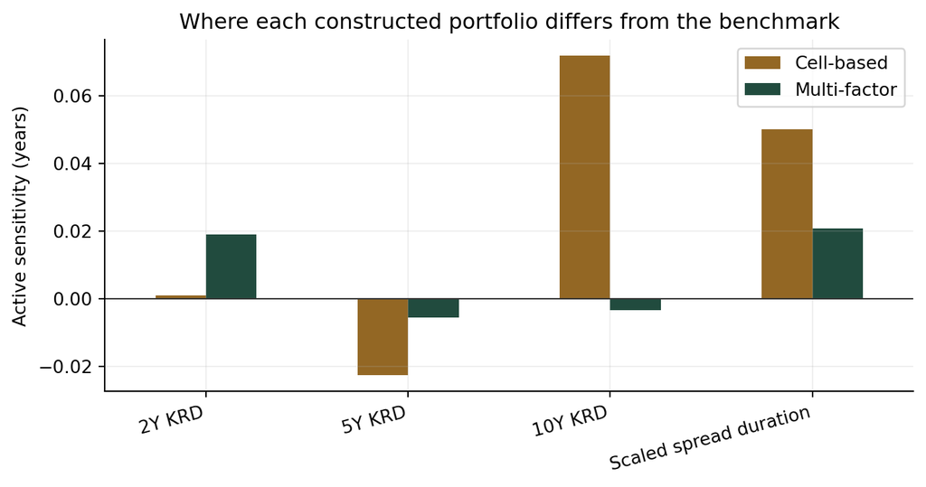

```python
show_table(comparison[['Yield proxy (%)','Duration (years)','Annual TE (bp)']].reset_index(names='Portfolio'),3)
show_table(comparison[['Treasury (%)','Corporate (%)','Largest bond (%)']].reset_index(names='Portfolio'),2)
show_table(comparison[['Average spread (bp)']].reset_index(names='Portfolio'),2)
active_factor_exposures=pd.DataFrame({name:(w-benchmark)@exposures for name,w in portfolios.items()
                                     if name!='Benchmark'},index=['2Y KRD','5Y KRD','10Y KRD','Scaled spread duration'])
ax=active_factor_exposures.plot.bar(color=['#936724','#214b3e'])
ax.axhline(0,color='#333',linewidth=.8)
ax.set(ylabel='Active sensitivity (years)',xlabel='',title='Where each constructed portfolio differs from the benchmark')
plt.xticks(rotation=15,ha='right');plt.tight_layout();plt.show()
```

Exact cell matching does not imply exact factor matching. Bonds in one cell can have different key-rate durations, spread sensitivities, and residual risk. The multi-factor result has the smallest modeled TE among portfolios satisfying the common mandate. This does not establish higher future realized returns or robustness to a misspecified covariance model.

### 6.4 Explain the sources of predicted risk

The following amounts add in **variance**, not standard deviations. The factor contribution for factor $k$ is $z_k(\Sigma_Fz)_k$, where $z=a'L$. A contribution can be negative when covariance offsets other active risks.

**Show calculation**

```python
risk_rows=[]
for name,w in portfolios.items():
    if name=='Benchmark':continue
    active=w-benchmark; z=active@loadings
    contributions=z*(factor_covariance_bp2@z)
    residual=np.sum((active*specific_vol_bp)**2)
    assert np.isclose(contributions.sum()+residual,tracking_variance(w),atol=1e-8)
    for factor,amount in zip(factor_names+['Independent residuals'],[*contributions,residual]):
        risk_rows.append({'Portfolio':name,'Source':factor,'Variance (bp²)':amount})
show_table(pd.DataFrame(risk_rows),3)
```

| Portfolio | Source | Variance (bp²) |
| --- | --- | --- |
| Cell-based | 2Y Treasury yield | 0.159 |
| Cell-based | 5Y Treasury yield | -7.215 |
| Cell-based | 10Y Treasury yield | 34.037 |
| Cell-based | Common spread | 10.513 |
| Cell-based | Independent residuals | 37.795 |
| Multi-factor | 2Y Treasury yield | 1.104 |
| Multi-factor | 5Y Treasury yield | -0.216 |
| Multi-factor | 10Y Treasury yield | -0.078 |
| Multi-factor | Common spread | 1.539 |
| Multi-factor | Independent residuals | 3.674 |

## 7 Turn initial cash into purchase orders

These are **initial purchases from cash**. Multiply each portfolio weight by $50 million to obtain the bond’s market-value allocation. The purchase values must sum to exactly the initial capital.

Market value is the full settlement value, including accrued interest. Converting it to face amount requires the full price per $100 face, feasible lots, and available inventory. The calculated model prices are not executable quotes, and no lot-size or inventory assumptions are supplied, so the table remains a market-value allocation plan rather than executable face-amount tickets.

**Show calculation**

```python
purchase_tables={}
for name,w in portfolios.items():
    if name=='Benchmark':continue
    values=purchase_values(w)
    table=pd.DataFrame({'Bond':universe['Bond'],'Weight (%)':100*w,'Buy ($m)':values/1e6})
    purchase_tables[name]=table
    display(Markdown('**'+name+' initial purchase plan**'))
    show_table(table,3)
    assert np.isclose(values.sum(),budget,atol=.01,rtol=0)
show_table(pd.DataFrame({'Method':['Cell-based','Multi-factor'],
                        'Total purchases ($)':[f'{purchase_values(cell_weights).sum():,.2f}',
                                               f'{purchase_values(factor_weights).sum():,.2f}']}),2)
```

**Cell-based initial purchase plan**

| Bond | Weight (%) | Buy ($m) |
| --- | --- | --- |
| UST 2Y | 10.000 | 5.000 |
| UST 5Y | 13.000 | 6.500 |
| UST 10Y | 10.000 | 5.000 |
| Agency 3Y | 9.000 | 4.500 |
| Agency 7Y | 10.000 | 5.000 |
| Bank A 3Y | 7.000 | 3.500 |
| Bank B 5Y | 5.253 | 2.626 |
| Utility A 7Y | 8.437 | 4.219 |
| Industrial A 10Y | 4.500 | 2.250 |
| Industrial B 5Y | 6.985 | 3.492 |
| Telecom A 10Y | 7.500 | 3.750 |
| Consumer A 7Y | 8.326 | 4.163 |

**Multi-factor initial purchase plan**

| Bond | Weight (%) | Buy ($m) |
| --- | --- | --- |
| UST 2Y | 7.682 | 3.841 |
| UST 5Y | 9.953 | 4.977 |
| UST 10Y | 9.663 | 4.832 |
| Agency 3Y | 12.098 | 6.049 |
| Agency 7Y | 12.969 | 6.484 |
| Bank A 3Y | 7.387 | 3.693 |
| Bank B 5Y | 8.897 | 4.448 |
| Utility A 7Y | 7.638 | 3.819 |
| Industrial A 10Y | 6.449 | 3.225 |
| Industrial B 5Y | 7.302 | 3.651 |
| Telecom A 10Y | 5.007 | 2.503 |
| Consumer A 7Y | 4.954 | 2.477 |

| Method | Total purchases ($) |
| --- | --- |
| Cell-based | 50,000,000.00 |
| Multi-factor | 50,000,000.00 |

## 8 Stress the completed portfolios

A parallel Treasury shock changes all three zero-curve nodes equally. A twist changes them by different amounts. For a parallel rate change, duration and convexity provide the familiar approximation:

$$\Delta P_i/P_i\approx-D_i\Delta y-\beta_iSD_i\Delta s
+\tfrac12 C_i(\Delta y)^2.$$

The **scenario tables and interactive controls reprice every cash flow** using the shocked zero curve and spread. They do not switch approximations when the curve changes shape. Full repricing includes rate and spread convexity and their interaction under this fixed-cash-flow model.

The scenarios are instantaneous price changes, excluding carry, defaults, residual-return shocks, and reinvestment. No probabilities are assigned.

**Show calculation**

```python
def reprice_bonds(shocks):
    # Three localized zero-node changes and one common-spread change, all in bp.
    shocks = np.asarray(shocks, dtype=float)
    if shocks.shape != (4,) or not np.isfinite(shocks).all():
        raise ValueError('Supply four finite factor shocks in basis points.')
    rates = (base_rates + (key_basis @ shocks[:3])[None, :] / 10000
             + spread_beta[:, None] * shocks[3] / 10000)
    if np.any(1 + rates / 2 <= 0):
        raise ValueError('Shocked discount factors require positive compounding bases.')
    return np.sum(cashflows / (1 + rates / 2)**(2 * payment_times), axis=1)

def scenario_return(weights,shocks):
    return weights @ (reprice_bonds(shocks) / full_prices - 1)

scenarios={'Parallel +50 bp':[50,50,50,0],'Bear steepener':[20,45,80,15],
           'Bull flattener':[-20,-55,-90,-10],'Spread +100 bp':[0,0,0,100]}
def scenario_pnl(weights,shocks):
    return budget * scenario_return(weights,shocks)
scenario_results=pd.DataFrame({name:{label:scenario_pnl(w,shocks)/1e6
                 for label,shocks in scenarios.items()} for name,w in portfolios.items()})
assert np.linalg.eigvalsh(factor_covariance_bp2).min()>0
assert np.linalg.eigvalsh(security_covariance_bp2).min()>0
assert np.allclose(universe[['KRD 2','KRD 5','KRD 10']].sum(axis=1),durations)
assert tracking_variance(benchmark)==0
assert tracking_variance(factor_weights)<=tracking_variance(cell_weights)+1e-5
# Check the curve convention and analytical sensitivities against full repricing.
assert np.allclose(key_basis.sum(axis=1), 1, atol=1e-12, rtol=0)
assert np.allclose(universe.loc[maturities <= 2, ['KRD 5','KRD 10']], 0, atol=1e-12, rtol=0)
assert np.allclose(universe.loc[maturities <= 5, 'KRD 10'], 0, atol=1e-12, rtol=0)
assert np.allclose(reprice_bonds(np.zeros(4)), full_prices, atol=1e-10, rtol=0)
assert (cashflows >= 0).all() and (full_prices > 0).all()
assert np.isfinite(universe[['Yield','Duration','Convexity']].to_numpy()).all()
h = 1e-5  # A 0.1 bp node bump, expressed as an annualized decimal rate.
for k in range(4):
    shock = np.zeros(4); shock[k] = h * 10000
    measured = -(reprice_bonds(shock)-reprice_bonds(-shock))/(2*h*full_prices)
    assert np.allclose(measured, exposures[:,k], atol=1e-7, rtol=1e-6)
parallel = np.array([1.,1.,1.,0.])
hc = 1e-4
p_up = reprice_bonds(parallel*hc*10000)
p_down = reprice_bonds(-parallel*hc*10000)
measured_convexity = (p_up+p_down-2*full_prices)/(hc**2*full_prices)
assert np.allclose(measured_convexity, universe['Convexity'], atol=1e-5, rtol=5e-6)
```

### 8.1 Compare scenario profit and loss

All three portfolios use the same $50 million capital base. Multiply the repriced portfolio return by that amount to obtain scenario P&L. No annual carry is added to the instantaneous price change.

**Show calculation**

| Scenario | Benchmark | Cell-based | Multi-factor |
| --- | --- | --- | --- |
| Parallel +50 bp | -1.209 | -1.222 | -1.212 |
| Bear steepener | -1.512 | -1.538 | -1.513 |
| Bull flattener | 1.752 | 1.782 | 1.751 |
| Spread +100 bp | -1.320 | -1.344 | -1.331 |

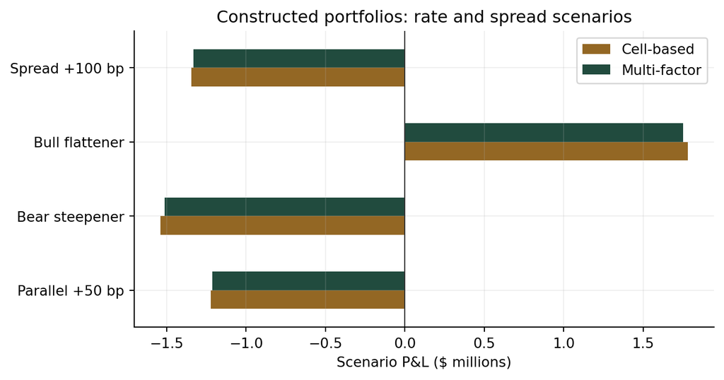

```python
show_table(scenario_results.reset_index(names='Scenario'),3)
ax=scenario_results[['Cell-based','Multi-factor']].plot.barh(color=['#936724','#214b3e'])
ax.axvline(0,color='#333',linewidth=.8)
ax.set(xlabel='Scenario P&L ($ millions)',ylabel='',title='Constructed portfolios: rate and spread scenarios')
plt.tight_layout();plt.show()
```

## 9 Explore construction choices and factor shocks

The HTML tools use the calculated allocations and risk matrix above. The PDF contains the corresponding tables and figures. These controls perform local calculations; they do not request market data or solve a new optimization.

### 9.1 Move between the two feasible construction plans

A weighted mixture of the two plans remains feasible because all mandate constraints are linear in portfolio weights. The risk model evaluates each mixture; it need not be a linear average of the two endpoint tracking errors.

Weight on the multi-factor plan: 100%

This is a mixture of two fixed purchase plans, not a freshly optimized portfolio.

### 9.2 Change the four market factors explicitly

The default is a +50 bp parallel Treasury move and +25 bp common-spread widening. Set only one Treasury slider to a nonzero value to isolate a key-rate shock. Set all three Treasury sliders to the same value for a parallel shift.

Construction method 2Y Treasury yield change: 50 bp 5Y Treasury yield change: 50 bp 10Y Treasury yield change: 50 bp Common-spread change: 25 bp

## 10 Validate and interpret the decision

The calculations compare all four analytical factor sensitivities and parallel convexity with numerical repricing, including zero exposure beyond a short bond’s maturity. They also check that weights sum to one, no short positions appear, every common mandate limit passes, exact cells match under the cell method, the covariance matrices are positive definite, and purchase values reconcile to the initial cash. The multi-factor portfolio is also checked to have no more modeled TE than the feasible cell portfolio under the same common mandate.

The cell method matches benchmark buckets and minimizes individual weight differences within them. The multi-factor method explicitly accounts for co-movement and residual risk. Neither method is guaranteed to outperform. Before investing, verify security data, issuer relationships, executable prices, and feasible lot sizes, then rerun the constraints on the rounded purchase plan.

## 11 Mini project: raise the yield-proxy requirement

Raise the minimum weighted-yield increment from **2 bp to 5 bp above the benchmark**, keeping every other input and limit fixed.

1. Determine whether exact cell matching can meet the revised requirement.
2. Find the maximum attainable yield proxy under exact cells and the other limits.
3. Construct a multi-factor target under the revised floor, if feasible.
4. Report its annual TE, duration, sector weights, and purchase-budget reconciliation.
5. Explain which requirement would need to change if a method is infeasible.

Do not label an infeasible solution a portfolio. Do not interpret a higher yield proxy as a guaranteed expected excess return.

**Worked solution: feasibility and the revised construction**

**Show calculation**

```python
# Maximize carry subject to exact cells and every other limit.
cell_max_yield = construct('Cell-based',0.,maximize_carry=True)
cell_carry_ceiling_bp = (cell_max_yield@yields-benchmark_yield)*10000
project_factor_weights = construct('Multi-factor',.0005)
```

**Show calculation**

```python
display(Markdown(f"The greatest exact-cell yield increment is **{cell_carry_ceiling_bp:.3f} bp**, "
                 "below the revised 5 bp floor. Exact cell matching is infeasible under the revised mandate."))
project_summary=pd.DataFrame({'Multi-factor, +5 bp floor':summary(project_factor_weights)}).T
show_table(project_summary[['Yield proxy (%)','Duration (years)','Annual TE (bp)']].reset_index(names='Target'),3)
show_table(project_summary[['Treasury (%)','Corporate (%)','Largest bond (%)']].reset_index(names='Target'),2)
values=purchase_values(project_factor_weights)
show_table(pd.DataFrame({'Bond':universe['Bond'],'Weight (%)':100*project_factor_weights,
                        'Initial buy ($m)':values/1e6}),3)
assert (project_factor_weights@yields-benchmark_yield)*10000 >= 5-1e-5
assert cell_carry_ceiling_bp < 5
assert np.isclose(values.sum(),budget,atol=.01,rtol=0)
display(Markdown(f"The initial bond purchases use exactly **${values.sum():,.2f}** of capital."))
```

The greatest exact-cell yield increment is **4.382 bp**, below the revised 5 bp floor. Exact cell matching is infeasible under the revised mandate.

| Target | Yield proxy (%) | Duration (years) | Annual TE (bp) |
| --- | --- | --- | --- |
| Multi-factor, +5 bp floor | 5.137 | 4.938 | 7.689 |

| Target | Treasury (%) | Corporate (%) | Largest bond (%) |
| --- | --- | --- | --- |
| Multi-factor, +5 bp floor | 25.00 | 50.00 | 13.30 |

| Bond | Weight (%) | Initial buy ($m) |
| --- | --- | --- |
| UST 2Y | 6.594 | 3.297 |
| UST 5Y | 8.906 | 4.453 |
| UST 10Y | 9.500 | 4.750 |
| Agency 3Y | 11.704 | 5.852 |
| Agency 7Y | 13.296 | 6.648 |
| Bank A 3Y | 8.673 | 4.336 |
| Bank B 5Y | 8.389 | 4.195 |
| Utility A 7Y | 6.944 | 3.472 |
| Industrial A 10Y | 5.009 | 2.504 |
| Industrial B 5Y | 8.815 | 4.408 |
| Telecom A 10Y | 6.336 | 3.168 |
| Consumer A 7Y | 5.833 | 2.917 |

The initial bond purchases use exactly **$50,000,000.00** of capital.

The exact-cell approach would require a lower yield floor, different cell budgets, a broader investable universe, or another relaxed constraint. The multi-factor approach meets the revised floor by using its freedom across cells, with greater active risk than its original 2 bp target. That is a construction tradeoff, not evidence of a free improvement.